# Positive density dependence in seedlings of the neotropical tree species Garcinia macrophylla and Xylopia micans - Anderson - 2009 - Journal of Vegetation Science - Wiley Online Library

[Journal of Vegetation Science](https://onlinelibrary.wiley.com/journal/16541103)

[Volume 20, Issue 1](https://onlinelibrary.wiley.com/toc/16541103/2009/20/1) p. 27-36

[figure not shown]

Full Access

# Positive density dependence in seedlings of the neotropical tree species *Garcinia macrophylla* and *Xylopia micans*

[Jill T. Anderson](https://onlinelibrary.wiley.com/action/doSearch?ContribAuthorStored=Anderson%2C+Jill+T),

First published: 23 February 2009

https://doi.org/10.1111/j.1654-1103.2009.05272.x

Citations: 7

Corresponding author; Tel.+1 6072544285; Fax+1 6072558088; E-mail jta24@cornell.edu

Co-ordinating Editor: Z. Münzbergová.

## Abstract

**Question:** The Janzen-Connell hypothesis predicts that herbivores and pathogens prevent seedlings from establishing in dense patches near adult conspecifics. Although many studies have investigated the Janzen-Connell hypothesis, the environmental context – local or regional – in which juveniles establish is often overlooked. The objectives of this study were: (1) to evaluate Janzen-Connell effects in contrasting environments, and (2) to incorporate microsite variation into the study of this hypothesis.

**Location:** Pacaya-Samiria Reserve, Peru.

**Methods:** I assessed seedling performance of two tree species, *Garcinia macrophylla* and *Xylopia micans*, during one growing season. In an observational study, mortality and growth rates were regressed against distance to the nearest adult conspecific, conspecific seedling density, heterospecific plant density, and several abiotic variables in upland and floodplain forests. Field and shadehouse experiments were used to isolate distance- and density-dependent effects.

**Results:** Contrary to predictions, seedling survivorship increased in the presence of conspecific seedlings (*Garcinia*) and heterospecific understory plants (*Garcinia* and *Xylopia*) in the observational study. Survivorship in the field experiment, however, was unaffected by conspecific seedling density or adult proximity. In the shadehouse, *Garcinia* growth rates were highest in floodplain soils collected near adult conspecifics, but mortality was unrelated to the soil's habitat or proximity to an adult.

**Conclusions:** The positive density dependence found in this study could have been produced by: (1) environmental factors that increase both density and survivorship, or (2) interspecific facilitation, if heterospecifics reduce herbivore or pathogen pressure on the focal species. Such interactions could help explain species coexistence in tropical forests.

## Introduction

Host-specific natural enemies that attack aggregations of seeds and seedlings may effectively reduce the advantage of abundant species relative to rare species, thereby facilitating species coexistence (Janzen 1970; Connell 1971). The Janzen-Connell hypothesis predicts that juvenile performance should increase with distance to the nearest adult conspecific, and decrease with juvenile density (Janzen 1970; Connell 1971). No clear consensus, however, has emerged on the prevalence of Janzen-Connell effects in tropical or temperate systems (Carson et al. in press). The distance-dependent component of the hypothesis may operate for seedlings, but is not a general phenomenon at the seed stage (Hyatt et al. 2003, a meta-analysis of 75 species). Furthermore, seedlings show complex responses to conspecific density that are not consistent across species (e.g. Augspurger & Kelly 1984; Clark & Clark 1984; Condit et al. 1994).

Surprisingly few tests have investigated density- and distance-dependent mortality in the environmental context in which seedlings establish (but see Augspurger 1983; Wills & Condit 1999; Gilbert et al. 2001; Sullivan 2003; Norghauer et al. 2006). Fine-scale heterogeneity in resource levels or in the identity and abundance of heterospecifics could conceal or mimic patterns of distance- and density-dependent mortality (Condit et al. 1994; Stevens & Carson 1999). Indeed, recruitment could be limited by environmental factors other than natural enemies. Environmental heterogeneity clearly influences species diversity and distribution patterns at large scales (Ruokolainen & Tuomisto 2002; Jones et al. 2006); yet little is known about how local environmental variation affects mortality and growth of tropical seedlings (but see Baraloto et al. 2005a; Bunker & Carson 2005). Many tropical tree species do, however, exhibit nonrandom distribution and recruitment patterns with respect to edaphic conditions, topography, and light availability (e.g. Clark et al. 1998; Kobe 1999; Harms et al. 2001; Dalling & Hubbell 2002; Balderrama & Chazdon 2005; John et al. 2007; Jones et al. 2007). Microhabitat associations early in ontogeny can be strict; evaluating the abiotic and biotic factors that enhance survivorship, therefore, should lead to a deeper understanding of recruitment and species coexistence (Grubb 1977).

Heterospecific plants can also influence the establishment success of juveniles. In diverse systems like tropical forests, an individual's nearest neighbors are likely to be heterospecific plants whose presence may reduce the apparency of a focal species to attack by natural enemies (Feeny 1976; Peters 2003). In that case, juvenile performance would increase with heterospecific density and diversity (Peters 2003; Webb et al. 2006). Such interspecific facilitation would promote species coexistence, but heterospecifics are rarely considered in tests of the Janzen-Connell hypothesis.

It has been proposed that Janzen-Connell effects are stronger in tropical than temperate forests due to higher pathogen and herbivore pressure in aseasonal tropical environments, and that this difference contributes to the latitudinal gradient in species diversity (Janzen 1970; Connell 1971; Coley & Barone 1996; Givnish 1999; but see Hille Ris Lambers et al. 2002). It is not known whether *within* a latitudinal belt, distance- and density-dependent factors are more prevalent in abiotically benign vs. stressful environments, and if so, whether they can explain local or regional gradients in species diversity. Tropical systems that experience prolonged abiotic stresses harbor fewer species than aseasonal terra firme forests (e.g. Ferreira 2000; Fajardo et al. 2005). For example, in Amazonian floodplain forests, plant species diversity is inversely related to flooding duration (Kvist & Nebel 2001). Flooding presents a severe physiological stress to plants, especially in Amazonian floodplain forests where subcanopy plants may remain completely submerged for months (Parolin et al. 2004). Flooding may also be stressful for host-specific herbivores, pathogens, and seed predators. If natural enemies of seeds and seedlings cannot maintain viable populations during the flooded season, they would need to recolonize floodplain forest floors in the non-flooded season from upland areas, from dormant propagules, or from tree canopies. Floodplain forests show a flush of germination immediately after flood waters recede (Parolin et al. 2004) when population densities of natural enemies may be low. In upland forests, natural enemy populations most likely remain relatively constant through time. Janzen-Connell effects could, therefore, be weaker in floodplain than in upland forests.

The objectives of this study were twofold: (1) to evaluate the strength of Janzen-Connell effects in contrasting environments (upland vs. floodplain forests), and (2) to incorporate microsite variation into the study of distance and density dependence in the field. Seedling mortality is highest during initial establishment (e.g. Baraloto et al. 2005b); therefore, this study was focused on the critical period of post-germination performance of two Peruvian tree species. An observational study was designed to test the Janzen-Connell hypothesis while simultaneously identifying abiotic or biotic parameters that enhance establishment in naturally-recruiting seedlings. Experimental studies in the field and a shadehouse isolated the effects of distance to the nearest adult conspecific and conspecific seedling density from other correlates of seedling performance. For both the observational study and the field experiment, seedling performance was assessed around multiple adult conspecifics in both habitats.

## Material and Methods

### Study system and focal species

Pacaya-Samiria is a 2.15 million ha reserve in northeastern Peru, ca. 80% of which floods annually (Kvist & Nebel 2001; Tapia et al. 2000). The study began in July 2003 after flood waters receded from floodplain forests in the northeastern section of the reserve (04°49′ S, 73°46′ W). Flooding occurs for two to three months per year in floodplain forests to a depth of 1–2.5 m, but only infrequently in adjacent upland forests (Kvist & Nebel 2001); local naturalists indicate that the uplands have not been flooded in ca. 15 years (A. Velazquez Velazquez pers. comm.). Upland forests in Pacaya-Samiria have higher species diversity than floodplain forests (Tapia et al. 2000). In general, tree species overlap is low between upland and floodplain forests in blackwater Amazonian systems (Ferreira 2000).

*Garcinia macrophylla* (*Clusiaceae*; hereafter *Garcinia*) and *Xylopia micans* (*Annonaceae*; hereafter *Xylopia*) coexist and are moderately abundant canopy tree species (ca. 5–10 adults/ha, unpublished data, also see appendix A in Nebel et al. 2001). *Garcinia* and *Xylopia* are among the few species capable of tolerating conditions across a broad flooding gradient and they provided a unique opportunity to compare the strength of Janzen-Connell effects in contrasting habitats. Voucher specimens were deposited in the herbarium of the Universidad de la Amazonia Peruana, Iquitos, Peru.

### Observational study

Plots were placed haphazardly around focal trees to maximize variation in conspecific seedling density (*Garcinia* range: 1–41 seedlings/0.5 m<sup>2</sup> plot; *Xylopia* range: 1–31 seedlings/0.5 m<sup>2</sup> plot) and in distance to adult conspecifics (*Garcinia* range: 0.4–31.4 m; *Xylopia* range: 0.2–34 m; App. 1). Seedling densities (App. 1) fall within the range found in other tropical seedling plots (Augspurger 1984; Bunker & Carson 2005).

Within each plot, I recorded conspecific seedling density, heterospecific density (in 3 categories: trees >5 m tall, saplings and shrubs 20 cm–5 m tall, and seedlings ≤20 cm tall), distance to the nearest adult conspecific, soil pH (Kelway pH meter, Kel Instruments, Wyckoff, NJ), depth of the organic matter in the soil, and light availability (using hemispherical photography). Soil moisture and bulk density (dry weight/volume) were also quantified in *Xylopia* plots by taking one soil core immediately adjacent to each plot. Hemispherical photos are commonly used to estimate the light available to plants in the understory (e.g. Wang & Augspurger 2004). Photos were taken at dawn and dusk or under an overcast sky, using a Nikon N70, a fish-eye lens, and a tripod, 45 cm above the forest floor. Images were digitized and analysed with Gap Light Analyzer, which provided data on the degree of canopy openness, effective leaf area index, and direct and diffuse solar radiation transmitted through the canopy (Frazer et al. 1999).

Height and leaf number were measured for all *Garcinia* and *Xylopia* seedlings at the beginning of the dry season (*Garcinia*: July through mid-August; *Xylopia*: August through early September 2003) and re-measured before the flooded season (*Garcinia*: late October to early November; *Xylopia*: late November 2003). The number of leaves that showed herbivore or pathogen damage was also quantified. Seedling performance of *Garcinia* was assessed for a period of 3 months during the dry season; for *Xylopia* seedlings the period was only 2 months because *Garcinia* dispersed seeds earlier than *Xylopia* adults. This time period encompasses the critical early establishment phase.

Performance was quantified through mortality and relative growth rate in leaf number (RGR). RGR was calculated as (ln(*L*<sub>f</sub>)−ln(*L*<sub>i</sub>))/*t*, where *L*<sub>f</sub> is the final number of leaves, *L*<sub>i</sub> is the initial leaf number, and t is elapsed time in months (Bunker & Carson 2005). RGR in leaf number serves as a better metric than RGR in height for small seedlings because of inaccuracies in height measurement over short census intervals in the field (Bunker & Carson 2005). For *Xylopia* seedlings, cotyledons were scored as half a leaf because they are small yet photosynthetically active. At remeasurement, several living seedlings had no leaves; therefore, 0.5 leaves was added to final and initial leaf number of all seedlings because of the natural log transformation in the calculation of RGR.

### Field experiment

To isolate the effects of distance and density, *Garcinia* and *Xylopia* seedlings were planted in a fully factorial experiment in the field with two distance categories (near:<1m from an adult conspecific, and far: 30 m from the nearest adult conspecific), and two density treatments (sparse and dense). All naturally-recruiting seedlings within a 1 m radius of transplantation locations were cleared. For both species, the sparse treatment consisted of 1 transplanted seedling. The dense treatment consisted of 5 seedlings planted in a pentagon 5 cm apart for *Garcinia*, and 4 seedlings planted in a square 5 cm apart for *Xylopia*, which exceeded the density of naturally-recruited seedlings from the observational study (App. 1). The far distance (30 m) was deemed to be outside of the influence of the adult conspecific and occurred where the abundance of seedlings declined naturally (unpubl. data). Recently-germinated seedlings 15–20 m from multiple adult conspecifics were collected in both upland and floodplain sites, to minimize previous herbivore damage and reduce the probability that host-specific pathogens or mycorrhizae would have colonized the roots. All treatment combinations were planted around a given adult conspecific (*Garcinia: n*=10 adult trees in upland forests, and 9 in floodplain forests; *Xylopia: n*=14 adult trees in upland forests and 7 in floodplain forests). This experiment began in July (*Garcinia*) and August (*Xylopia*) 2003, and mortality was assessed after 3 months.

### Shadehouse experiment

To explore potential distance-dependent effects in this system, Packer & Clay's (2000) greenhouse experiment was modified. *Xylopia* and *Garcinia* seedlings were grown in upland and floodplain soil collected from within 2 m of the base of *Xylopia* and *Garcinia* adult conspecifics respectively (near treatment) and from at least 30 m distance from any *Xylopia* or *Garcinia* adult (far treatment). An additional sterilization treatment was implemented for *Xylopia* (but not *Garcinia*) seedlings. Half of the soil for *Xylopia* seedlings from each treatment was sterilized by conventional microwaving of approximately 1.5 kg in a plastic bag for 5 minutes. Soil sterilization by microwave does not alter nutrient composition to the same extent as sterilization by autoclave (Ferriss 1984). Seedlings used in this experiment were collected at least 20 m from adult conspecifics and were surface-sterilized in a dilute (5%) solution of bleach prior to planting. This sterilization removes fungal or bacterial pathogens and mutualists on the surface of the roots, but not in the interior of the root system (Meredith & Anderson 1992). Preliminary observations indicated that treatment in bleach did not impede subsequent performance. Seedlings were grown in a fully factorial experiment (*Garcinia*: distance by habitat treatments; *Xylopia*: distance by sterilization by habitat treatments) in a shadehouse for 6 (*Xylopia*) to 8.5 (*Garcinia*) months prior to the harvest (April 6–12 2004). Due to initial deaths, the experiment was unbalanced (Table 2 below).

Table 2. Survivorship results from shadehouse experiment. The odds ratios are shown for significant effects. DF error=135 for *Xylopia* and 122 for *Garcinia*. Sample sizes are as follows: *Xylopia*: Floodplain soil: near sterilized, *n*=21; near unsterilized, *n*=25; far sterilized, *n*=18; far unsterilized, *n*=20; Upland soil: near sterilized, *n*=12; near unsterilized, *n*=15; far sterilized, *n*=14; far unsterilized, *n*=19. *Garcinia*: Floodplain soil: near, *n*=30; far, *n*=21; Upland soil: near, *n*=38; far, *n*=38.

|  | *Xylopia micans* Odds ratio (95% CI) | *Xylopia micans* *χ* <sup>2</sup> | *Xylopia micans* *p*-value | *Garcinia macrophylla* Odds ratio ± SE | *Garcinia macrophylla* *χ* <sup>2</sup> | *Garcinia macrophylla* *p*-value |
| --- | --- | --- | --- | --- | --- | --- |
| Initial height |  | 0.45 | 0.52 | 0.98 (0.97, 1.0) | 4.48 | 0.034 |
| Distance |  | 1.3 | 0.11 |  | 0.1 | 0.749 |
| Sterilization |  | 0.47 | 0.18 |  | N/A | N/A |
| Habitat | 2.7 (0.62, 12.7) | 7.87 | 0.0021 |  | 1.4 | 0.24 |
| Distance by sterilization |  | 0.84 | 0.14 |  | N/A | N/A |
| Habitat by distance |  | 2.09 | 0.07 |  | 0.3 | 0.59 |
| Habitat by sterilization |  | 0.44 | 0.21 |  | N/A | N/A |

### Data analysis

Analyses for the two species were conducted separately using SAS/STAT (v. 9.1.3, SAS Institute, Cary, NC). Explanatory variables were standardized– (data point-mean)/standard deviation – to compare the effects of parameters measured using different units. Score statistics from type III sums of squares were used to assess significance for all analyses. Following the guidelines of Maron (2003), Bonferroni corrections for multiple tests were not made.

### Observational study

Principal component analysis (PCA) was performed on light level data to reduce the number of explanatory variables. In the understory, hemispherical photos can overestimate the amount of direct photon flux density (Chazdon & Field 1987); therefore, only diffuse radiation was used in the PCA. The analyses defined one factor that represented 94.6% of the variation and had significant contributions from canopy openness (correlation=0.99), leaf area index (correlation=−0.95), and diffuse solar radiation (correlation=0.98). This factor represents light availability and was used in all subsequent analyses.

Mortality patterns were analysed using a generalized estimating equation (GEE) logistic regression (Genmod procedure); GEE is an extension of the generalized linear model approach and appropriately handles correlated data (Horton & Lipsitz 1999). To control for nonindependence, the data were modeled by nesting seedling within plot and plot within tree using a repeated statement (Horton & Lipsitz 1999). For both species, mortality was regressed against initial height (a covariate), distance to nearest adult conspecific, conspecific seedling density, heterospecific seedling and sapling density, soil pH, depth of organic matter, light availability and habitat type. Also two-way interaction terms were assessed between distance to nearest adult conspecific, conspecific seedling density, and habitat type. Regression models were selected by backward elimination (probability >0.10 to eliminate a variable). Change in log-likelihood statistics using a goodness-of-fit test were used to evaluate sequential models. These analyses were conducted at the individual-level; however plot-level mortality data are easier to visualize. Therefore, the data points in Fig. 1 represent plot-level seedling survivorship and the lines are predicted relationships from the individual-level analyses.

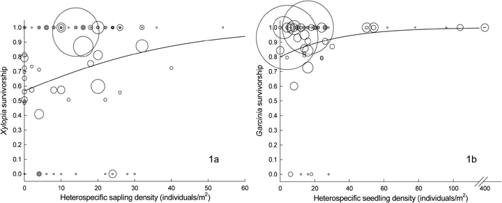

**Figure 1**

Observational study: (**a**) *Xylopia micans* seedling survivorship as a function of heterospecific sapling and small shrub density in both upland and floodplain forests combined (*p*=0.02). (**b**) *Garcinia macrophylla* seedling survivorship as a function of heterospecific seedling density for both upland and floodplain forests combined (*p*=0.036). Lines represent the predicted relationship (from the individual-level analyses), and the circles represent plot-level survivorship *N<sub>t</sub>*/*N<sub>o</sub>*)<sup>1/</sup>*<sup>t</sup>*, where *N<sub>t</sub>* is the final seedling density in a plot, *N<sub>o</sub>* is the initial seedling density, and *t* is elapsed time in months. The size of the circles indicates the conspecific seedling density within a plot.

Relative growth rates (RGR) of seedlings alive at the end of the study were regressed against the same main effects and interaction terms as the mortality analyses. Additionally, the severity of leaf damage was regressed against conspecific seedling density and distance to the nearest adult conspecific. A nested design accounted for the nonindependence of seedlings within plots, and plots at each tree (Proc Mixed, using a repeated statement with a compound symmetry structure).

### Experimental studies

Mortality was analysed for both species after 3 months for the field experiment with a nested design to account for nonindependence of seedlings planted around the same adult tree (repeated statement in Genmod procedure). For this analysis, one randomly selected individual from the dense treatment was identified as the focal individual to equalize the variance between the dense and the sparse treatments. For the shadehouse experiment, mortality and RGR were assessed for both species, and there was no correlated structure to this dataset. RGR for this experiment was calculated from initial and final height and analysed using the GLM procedure.

## Results

### Xylopia performance: observational study

Of 223 newly emerged *Xylopia* seedlings, 65 (29%) died during the study. Survivorship was positively associated with heterospecific sapling and shrub density (Table 1, Fig. 1a). Conspecific seedling density, distance to nearest adult, habitat, and initial leaf damage did not significantly affect survivorship, nor did any other main effects or interactions (Table 1).

Table 1. Logistic regression results from the observational study. The odds ratio (95% confidence Intervals) parameter estimates are given for variables retained in the final model. Parameters marked n.s. (not significant) had *p*>0.1. df error=221 for *Xylopia* and 269 for *Garcinia*.

|  | *Xylopia micans* Odds ratio (95% CI) | *Xylopia micans* *χ* <sup>2</sup> | *Xylopia micans* *p*-value | *Garcinia macrophylla* Odds ratio (95% CI) | *Garcinia macrophylla* *χ* <sup>2</sup> | *Garcinia macrophylla* *p*-value |
| --- | --- | --- | --- | --- | --- | --- |
| Initial height |  |  | n.s. | 2.66 (1.26, 5.65) | 6.69 | 0.0097 |
| Habitat |  |  | n.s. |  |  | n.s. |
| Conspecific seedling density |  |  | n.s. | 1.13 (1.0, 1.28) | 4.26 | 0.039 |
| Distance to adult conspecific |  |  | n.s. |  |  | n.s. |
| Heterospecific seedling density |  |  | n.s. | 6.3 (1.66, 23.76) | 4.36 | 0.037 |
| Heterospecific sapling density | 1.54 (1.04, 2.28) | 5.4 | 0.0201 |  |  | n.s. |
| Soil pH |  |  | n.s. |  |  | n.s. |
| Organic matter depth |  |  | n.s. |  |  | n.s. |
| Light availability |  |  | n.s. |  |  | n.s. |
| Conspecific seedling density × habitat |  |  | n.s. | 18.9 (2.66, 134.5) | 5.83 | 0.016 |
| Distance × habitat |  |  | n.s. |  |  | n.s. |

The positive heterospecific density dependence was not apparent in the analysis of relative growth rate in leaf number (RGR) for *Xylopia*. Instead, RGR was positively associated with light penetration to the understory (component 1 from the PCA: parameter estimate: 0.098 ± 0.04, *F*<sub>1,64</sub>=6.04, *p*=0.0167) and with soil moisture content (0.07 ± 0.03, *F*<sub>1,64</sub>=4.87, *p*=0.0309; average RGR was 0.059 leaves/leaf/month), but no other main effects of interaction terms were significantly associated with RGR.

### Garcinia performance: observational study

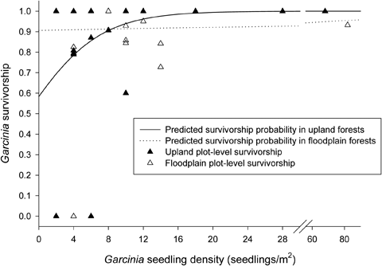

**Figure 2**

Observational study: *Garcinia macrophylla* seedling survivorship as a function of conspecific seedling density. Plot-level survivorship data (calculated as in Fig. 1) are graphed for both upland (filled triangles) and floodplain forests (unfilled triangles). The probability of survivorship is significantly associated with conspecific seedling density in upland forests, but not floodplain forests (*p*=0.015).

Relative growth rate was positively associated with organic matter depth in the soil (estimate=0.0064 ± 0.0027, *F*<sub>1,57</sub>=5.79, *p*=0.0194; the average RGR was 0.027 leaves/leaf/month), yet none of the other main effects or interaction terms significantly influenced RGR.

### Field experiment

Distance, conspecific seedling density, habitat and their interactions did not significantly predict *Xylopia* or *Garcinia* seedling mortality in the field experiment, even though 66% (206 of 311) of *Xylopia* seedlings and 31% (65 of 210) of *Garcinia* seedlings died during the experiment.

### Shadehouse experiment

During the shadehouse experiment, 25 (17.4%) of the initial 144 *Xylopia* seedlings died. *Xylopia* seedling survivorship was significantly greater in floodplain forest soil (89%) than upland soil (73%), suggesting, perhaps, higher resource availability in floodplain forests (Table 2). Similarly, seedlings exhibited higher relative growth rates in floodplain forest (mean+S.E.: 0.045 ± 0.003 cm cm<sup>−1</sup> mo<sup>−1</sup>) than in upland soil (0.023+0.004 cm cm<sup>−1</sup> mo<sup>−1</sup>; *F*<sub>1,111</sub>=21.63, *p*<0.0001). There was no significant effect of soil sterilization, distance of the soil collection from the nearest adult conspecific, or any interaction terms on RGR or mortality.

Of the initial 127 *Garcinia* seedlings, 84 (66%) died during the 8.5 month experiment. There was no significant effect of habitat or distance or their interaction on seedling survivorship (Table 2). Similarly, habitat (*F*<sub>1,35</sub>=0.51, *p*=0.48) and distance (*F*<sub>1,35</sub>=3.22, *p*=0.08) did not significantly influence the relative growth rate of seedlings that survived until the end of the experiment. In contrast, the interaction between habitat and distance was significant for *Garcinia* RGR (*F*<sub>1,35</sub>=5.09, *p*=0.030). This interaction showed that RGR was significantly greater in the near treatment (mean ± SE: 0.027 ± 0.0097 cm cm<sup>−1</sup> mo<sup>−1</sup>) in floodplain forest soil than the floodplain forest far treatment (–0.0094 ± 0.011 cm cm<sup>−1</sup> mo<sup>−1</sup>), and the far (0.0044 ± 0.0066 cm cm<sup>−1</sup> mo<sup>−1</sup>) and near (0.00027 ± 0.0074 cm cm<sup>−1</sup> mo<sup>−1</sup>) treatments in upland soil (App. 3).

## Discussion

The experimental and observational results for *Garcinia* and *Xylopia* seedlings were inconsistent with Janzen-Connell predictions of decreased performance with increasing conspecific seedlings density and proximity to adult conspecifics. Rather, the probability of *Garcinia* survivorship increased with conspecific seedling density in upland forests. Furthermore, the only distance dependency obvious in this dataset contradicted predictions from the Janzen-Connell hypothesis; in the shadehouse, *Garcinia* seedlings had higher growth rates in soil collected near adult conspecifics in floodplain forests than in any other treatment. Intriguingly, seedling survivorship increased with the density of heterospecific saplings and small shrubs (*Xylopia*) or heterospecific seedlings (*Garcinia*). These results suggest that positive intra- and interspecific interactions could arise from facilitation and/or localized regions of high resource availability (regeneration hotspots).

### Facilitation

Heterospecific plants could shield seedlings from host-specific natural enemies (Feeny 1976; Peters 2003). Indeed, Webb et al. (2006) suggest that pathogens are most likely to infect closely-related plant species, and that phylogenetic diversity enhances seedling survivorship by reducing disease transmission. Enhanced survivorship of *Garcinia* and *Xylopia* seedlings in the presence of heterospecifics could be driven by interspecific facilitation; however, the exact mechanism underlying this pattern is unknown because neither heterospecific plant density nor natural enemy abundance were manipulated experimentally in this study. If heterospecifics routinely protect seedlings from pathogens and herbivores, interspecific facilitation could contribute to the maintenance of high species diversity.

Intraspecific facilitation could also operate in this system. For example, if adults support mycorrhizal networks, seedling performance would increase with proximity to adult conspecifics (McGuire 2007). In the shadehouse experiment, *Garcinia* seedlings showed elevated growth rates in floodplain forest soil collected near adult conspecifics. This pattern is consistent with the hypothesis that Janzen-Connell effects may be less pronounced in abiotically stressful habitats such as floodplain forests. Mycorrhizae can flourish in flooded roots and enhance the flooding tolerance of plants (e.g. Fougnies et al. 2007). Furthermore, flooding has been used agriculturally to reduce population sizes of soil pathogens and nematodes that would otherwise damage crop plants (Katan 2000). It is possible that *Garcinia* adults harbor mutualists such as mycorrhizal fungi that could survive prolonged flooding within the root system, and attain relatively high densities near adults in floodplain forests. At the same time, annual floods in floodplain forests could potentially reduce soil pathogen populations. In contrast, pathogens could accumulate throughout the year in upland forests, and reduce the positive effects of mutualists.

It is possible that intraspecific facilitation could also be responsible for the positive conspecific density dependence of *Garcinia* seedlings. In that case, *Garcinia* performance would have increased with conspecific seedling density in experimental plantings. In the field manipulation, however, there was no significant effect of conspecific seedling density on survivorship for either species. Mortality in the field experiment exceeded mortality in the observational study; transplant shock may account for this difference. Nonetheless, intraspecific facilitation may not be as compelling an explanation for this pattern as regeneration hotspots.

### Regeneration hotspots

High quality microsites (i.e. regeneration hotspots) could promote both seedling survivorship and density, resulting in apparent positive interactions between juveniles. Within each habitat, I measured environmental variables that are known to influence plant growth and survivorship, i.e. light availability, soil compaction, leaf litter depth, depth of organic matter, and soil pH (Xiong & Nilsson 1999; Wenny 2000; Baraloto et al. 2005b; Eckstein & Donath 2005). These abiotic parameters did not significantly affect the probability of survivorship for either species, even though *Xylopia* growth rate was correlated with light availability and soil moisture content and *Garcinia* growth rate was correlated with organic matter depth. Nevertheless, abiotic conditions did influence heterospecific density within plots (App. 2); thus the increase in seedling performance with heterospecific density could have been produced by these abiotic factors. Additionally, unmeasured variables could drive the formation of regeneration hotspots. Such variables include soil nutrient availability and/or the presence of belowground mutualists, both of which are rarely quantified at a local scale in tropical forests (e.g. Clark et al. 1998; Paoli et al. 2006; John et al. 2007) and were not assessed in this study. Regeneration hotspots could account for both positive conspecific density dependence (*Garcinia*) and positive heterospecific density dependence (both species). The regeneration hotspot hypothesis predicts that positive conspecific density dependence would be detectable in the observational study because of localized areas of high resource availability, but absent in the field experiment because seedlings were planted randomly with respect to abiotic variables. This pattern holds for *Garcinia* seedlings, suggesting that the apparent positive interactions between conspecifics were mediated by abiotic factors.

### Comparison with other Janzen-Connell studies

A recent review of Janzen-Connell studies found that for most species, juvenile performance was unrelated to conspecific density and distance to the nearest adult conspecific (as with *Xylopia* in this study) or actually increased with conspecific density (as with *Garcinia* in this study) or proximity to an adult tree (Carson et al. in press). In contrast, Peters (2003) found that approximately 80% of the 732 species from two tropical forests exhibited negative density-dependent performance. The inconsistency in the direction and magnitude of Janzen-Connell effects found in published studies (e.g. Wills et al. 1997; Harms et al. 2000; John et al. 2002) could be a function of the abundance of focal species. Common species may show patterns more consistent with the Janzen-Connell hypothesis than rare species (Wills et al. 1997, 2006; Webb & Peart 1999), especially if common species support greater densities of host-specific enemies. For that reason, the positive conspecific seedling density dependence of *Garcinia* in this study may be a pattern that extends to other moderately abundant and rare species. Thus, natural enemies could help maintain plant species coexistence by preventing the most common species from dominating.

## Conclusions

Other than light availability, environmental correlates of seedling performance have rarely been assessed in tests of the Janzen-Connell hypothesis. In this study, survivorship of *Garcinia* seedlings increased with conspecific density in upland forests. It is likely that facilitation did not drive this positive intraspecific interaction because survivorship did not vary with conspecific density in experimental plantings. Rather, spatially localized regions of high resource availability (regeneration hotspots) could enhance both seedling density and survivorship. Seedlings of both *Xylopia* and *Garcinia* showed positive interactions with heterospecific neighbors, which may have been due to regeneration hotspots, or interspecific facilitation. Heterospecific plants could serve an important role in maintaining species diversity by protecting rare seeds and seedlings from attack (Peters 2003). Results from the shadehouse experiment indicate the Janzen-Connell effects may be reduced in abiotically stressful environments like floodplain forests. To understand species coexistence in diverse tropical forests, it is critical to evaluate the performance of the most vulnerable life history stages of tree species in relation to the local abiotic and biotic environment. Nonrandom seedling mortality due to heterogeneity in resource levels, and the density and diversity of neighborhood heterospecifics, may be common in tropical tree species, and may determine distribution patterns of future ontogenetic stages as well as species coexistence.

## Acknowledgments

**Acknowledgements.** I would like to thank A. Velazquez Velazquez, J. Garcia Velazquez, J. Barrera Macedo, and F. West for help in the field. D. del Castillo provided valuable logistical support. F. Vermeylen aided with the statistical analyses. This manuscript was greatly improved by comments from T. Pendergast, C. Vriesendorp, M. Geber, P. Marks, H. Schumacher, J. Bellemare, B. Barringer, L. Evanhoe, S. Reilly, R. Harris, A Parachnowitsch, Z. Münzbergová, T. Dostálek, and two anonymous reviewers. Permission to conduct this study was granted by the Peruvian National Institute of Natural Resources. A National Science Foundation Graduate Student fellowship supported this research.

## Citing Literature

[Volume20, Issue1](https://onlinelibrary.wiley.com/toc/16541103/2009/20/1)

February 2009

Pages 27-36

### Metrics

Citations: 7

### Details

© 2009 International Association for Vegetation Science

### Publication History

[Download PDF](https://onlinelibrary.wiley.com/doi/pdf/10.1111/j.1654-1103.2009.05272.x)

[back](https://onlinelibrary.wiley.com/doi/10.1111/j.1654-1103.2009.05272.x)